# Predicting Diabetes based on Diagnositc Measures

## Task

**The data is obtained from https://www.kaggle.com/uciml/pima-indians-diabetes-database. The aim of the task was to use machine learning to accurately predict whether or not the patients in the dataset have diabetes or not**

*The overall goal for this kaggle dataset was to improve on previous attempts by using more advanced machine learning algorithms. Therefore, this project included the following algorithms:*  
*- K- Nearest Neighbours (KNN)*  
*- Decision Tree*  
*- Random Forest*  
*- Support Vector Machines (SVM)*  
*- Artifical Neural Network*  
*- XGBoost*

*Within this project, there were also data analysis methodologies such as: Outlier Detection and Normalising, Redundant Features, Feature Importance and Feature Selection to help identify the important attributes and if further cleaning needs to be performed.*

Full report can be found on my github: https://github.com/TingHanGan/pima-indians-diabetes-prediction.

### Artifical Neural Network

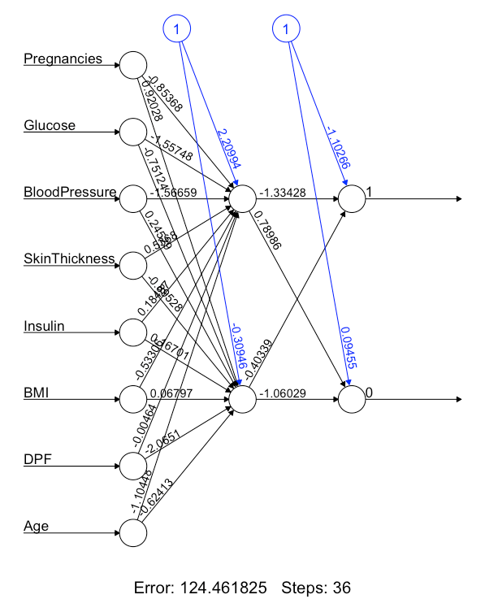